# 荷官—玩家风控体系｜数据质量审计与统计风险模型报告

- Show All Code
- Hide All Code
- View Source

player_pair_stat / dealer_profit_stat 四表联合分析

Author

Risk Analytics

Published

July 21, 2026

## 一、执行摘要 (Executive Summary)

本报告对风控体系四张核心表进行联合分析（已改用全量数据，非早期100行抽样）：

| 表名 | 定位 | 本次样本量 |
| --- | --- | --- |
| `player_pair_stat` | 玩家同桌关系风控候选表 | 100,000 行 |
| `player_pair_stat_hourly` | 玩家同桌关系小时快照表 | 100,000 行 |
| `dealer_profit_stat` | 荷官玩家获利风控候选表 | 100,000 行 |
| `dealer_profit_stat_hourly` | 荷官玩家获利小时快照表 | 100,000 行 |

**核心发现（按优先级排序，全部数字代码动态计算）：**

1. **数据质量优先级最高问题**：`dealer_profit_stat` 候选表100,000行中，`dealer_id=-1`（哨兵值）占比约4.5%，属于正常基线水平；但 **`risk_score`/`risk_level`/`dealer_std_roi`/`roi_zscore` 在全部行中100%无效**（`risk_score`恒为0，`risk_level`恒为`UNKNOWN`，后两者100%缺失，详见第二节动态核验）。这已排除”抽样偶然/排序截断”的可能性，**确认是评分计算链路的系统性故障**，需要工程团队排查（详见`top_tier_methodology_report.qmd`第二节）。
2. `player_pair_stat` 数据完整、可直接用于因子模型与网络分析，实际覆盖289个焦点玩家、44,433个不同搭档。
3. `dealer_profit_stat_hourly` 存在真实、可用的荷官层面盈利数据（147个真实荷官），是荷官风险分析真正应该切入的数据源。

## 二、数据质量审计 (Data Quality Audit)

```r
# 数据已在setup区块提前加载，此处仅做存在性确认，不重复读取
for (df in list(dps = dps, dph = dph, pps = pps, pph = pph)) {
  invisible(df)
}
```

### 2.1 缺失值与哨兵值扫描

```r
missing_report <- function(dt, name) {
  data.table(
    table = name,
    column = names(dt),
    missing_pct = sapply(dt, function(x) mean(is.na(x))) * 100
  )
}

dq <- rbindlist(list(
  missing_report(dps, "dealer_profit_stat"),
  missing_report(dph, "dealer_profit_stat_hourly"),
  missing_report(pps, "player_pair_stat"),
  missing_report(pph, "player_pair_stat_hourly")
))

dq[missing_pct > 0] |>
  gt(groupname_col = "table") |>
  fmt_number(columns = missing_pct, decimals = 1) |>
  data_color(
    columns = missing_pct,
    colors = scales::col_numeric(palette = c("white", "#d73027"), domain = c(0, 100))
  ) |>
  tab_header(title = "缺失值占比 (%) — 仅显示存在缺失的字段")
```

缺失值占比 (%) — 仅显示存在缺失的字段

| column | missing_pct |
| --- | --- |
| dealer_profit_stat |  |
| dealer_std_roi | 100.0 |
| roi_deviation | 100.0 |
| roi_zscore | 100.0 |

### 2.2 关键异常：dealer_profit_stat 候选表的哨兵值集中现象

```r
sentinel_summary <- data.table(
  检查项 = c(
    "dealer_profit_stat 中 dealer_id=-1 占比",
    "dealer_profit_stat_hourly 中 dealer_id=-1 占比",
    "dealer_profit_stat 中 risk_score=0 占比",
    "dealer_profit_stat 中 risk_level='UNKNOWN' 占比",
    "dealer_profit_stat 中 dealer_avg_roi=0 占比"
  ),
  数值 = c(
    mean(dps$dealer_id == -1) * 100,
    mean(dph$dealer_id == -1) * 100,
    mean(dps$risk_score == 0) * 100,
    mean(dps$risk_level == "UNKNOWN") * 100,
    mean(dps$dealer_avg_roi == 0) * 100
  )
)

sentinel_summary |>
  gt() |>
  fmt_number(columns = 数值, decimals = 1, pattern = "{x}%") |>
  data_color(columns = 数值, colors = scales::col_numeric(c("white", "#d73027"), c(0, 100))) |>
  tab_header(title = "哨兵值集中度诊断", subtitle = "候选表 vs 快照表对比，判断是排序问题还是链路问题")
```

哨兵值集中度诊断

候选表 vs 快照表对比，判断是排序问题还是链路问题

| 检查项 | 数值 |
| --- | --- |
| dealer_profit_stat 中 dealer_id=-1 占比 | 4.5% |
| dealer_profit_stat_hourly 中 dealer_id=-1 占比 | 6.0% |
| dealer_profit_stat 中 risk_score=0 占比 | 100.0% |
| dealer_profit_stat 中 risk_level='UNKNOWN' 占比 | 100.0% |
| dealer_profit_stat 中 dealer_avg_roi=0 占比 | 100.0% |

**诊断结论（已用全量10万行改写，纠正早期100行样本阶段的误判）**：候选表中 `dealer_id=-1` 占比为 4.5%，与快照表基线（6%）**处于同一量级，属正常波动**——这一点排除了”候选表排序/LIMIT截断导致哨兵值异常集中”这个早期基于100行样本提出的假设（100行样本里恰好100%全是哨兵值，属于小样本下的极端巧合，全量数据不支持这个假设）。真正的问题是：无论 `dealer_id` 是否为 -1，`risk_score` 恒为0的比例都是 100%（即全表100%），这与 `dealer_id` 是否哨兵**没有相关性**，说明问题出在 `risk_score`/`risk_level`/`dealer_std_roi`/`roi_zscore` 这条计算链路本身，而不是查询排序问题——与执行摘要第1点、`top_tier_methodology_report.qmd` 第二节的全量核实结论一致。建议工程团队直接排查评分计算任务，无需再走”重新导出验证排序”这一步。

### 2.3 逻辑一致性校验（数值范围合理性）

```r
logic_checks <- data.table(
  校验规则 = c(
    "player_a < player_b (排序规范性)",
    "same_round_count 不超过两玩家各自总局数下限",
    "same_rate 落在 [0,1] 区间",
    "win_rate 落在 [0,1] 区间",
    "profit_per_bet = profit / bet_count (容差1%)"
  ),
  通过率 = c(
    mean(pps$player_a < pps$player_b) * 100,
    mean(pps$same_round_count <= pmin(pps$player_a_rounds, pps$player_b_rounds)) * 100,
    mean(pps$same_rate >= 0 & pps$same_rate <= 1) * 100,
    mean(dps$win_rate >= 0 & dps$win_rate <= 1) * 100,
    mean(abs(dps$profit / dps$bet_count - dps$profit_per_bet) < abs(dps$profit_per_bet) * 0.01, na.rm = TRUE) * 100
  )
)

logic_checks |>
  gt() |>
  fmt_number(columns = 通过率, decimals = 1, pattern = "{x}%") |>
  data_color(columns = 通过率, colors = scales::col_numeric(c("#d73027", "white", "#1a9850"), c(0, 50, 100))) |>
  tab_header(title = "业务逻辑一致性校验")
```

业务逻辑一致性校验

| 校验规则 | 通过率 |
| --- | --- |
| player_a < player_b (排序规范性) | 100.0% |
| same_round_count 不超过两玩家各自总局数下限 | 100.0% |
| same_rate 落在 [0,1] 区间 | 100.0% |
| win_rate 落在 [0,1] 区间 | 100.0% |
| profit_per_bet = profit / bet_count (容差1%) | 100.0% |

`player_pair_stat` 全部逻辑校验通过，数据可信度高，可放心用于下一节的统计建模。

## 三、player_pair_stat 因子风险模型 (Multi-Factor Risk Model)

### 3.1 衍生因子构建

```r
pps[, `:=`(
  a_dependency    = same_round_count / player_a_rounds,
  b_dependency    = same_round_count / player_b_rounds,
  first_game_time = as.POSIXct(first_game_time),
  last_game_time  = as.POSIXct(last_game_time)
)]
pps[, max_dependency := pmax(a_dependency, b_dependency)]
pps[, duration_days   := as.numeric(difftime(last_game_time, first_game_time, units = "days"))]
pps[, days_since_last := as.numeric(difftime(Sys.time(), last_game_time, units = "days"))]

minmax <- function(x) (x - min(x, na.rm = TRUE)) / (max(x, na.rm = TRUE) - min(x, na.rm = TRUE) + 1e-9)
```

### 3.2 因子正交化诊断（顶级量化标准动作，非可选项）

在直接加权合成风险分之前，**先检验各因子之间是否存在高度共线性**——若 `same_rate` 与 `max_dependency` 高度相关，直接加权等同于对同一信号重复计权，会扭曲最终风险排序。

```r
factor_cols <- pps[, .(same_rate, max_dependency, same_round_count, duration_days, days_since_last)]

corr_matrix <- correlate(factor_cols, quiet = TRUE)
corr_matrix |> shave() |>
  gt() |>
  fmt_number(columns = -term, decimals = 2) |>
  data_color(
    columns = -term,
    colors = scales::col_numeric(c("#4575b4", "white", "#d73027"), domain = c(-1, 1), na.color = "white")
  ) |>
  tab_header(title = "因子相关性矩阵", subtitle = "|r| > 0.6 视为高度共线，需降权或剔除其一")
```

因子相关性矩阵

|r| > 0.6 视为高度共线，需降权或剔除其一

| term | same_rate | max_dependency | same_round_count | duration_days | days_since_last |
| --- | --- | --- | --- | --- | --- |
| same_rate | NA | NA | NA | NA | NA |
| max_dependency | 1.00 | NA | NA | NA | NA |
| same_round_count | −0.01 | −0.01 | NA | NA | NA |
| duration_days | −0.28 | −0.28 | 0.27 | NA | NA |
| days_since_last | 0.10 | 0.10 | −0.14 | −0.49 | NA |

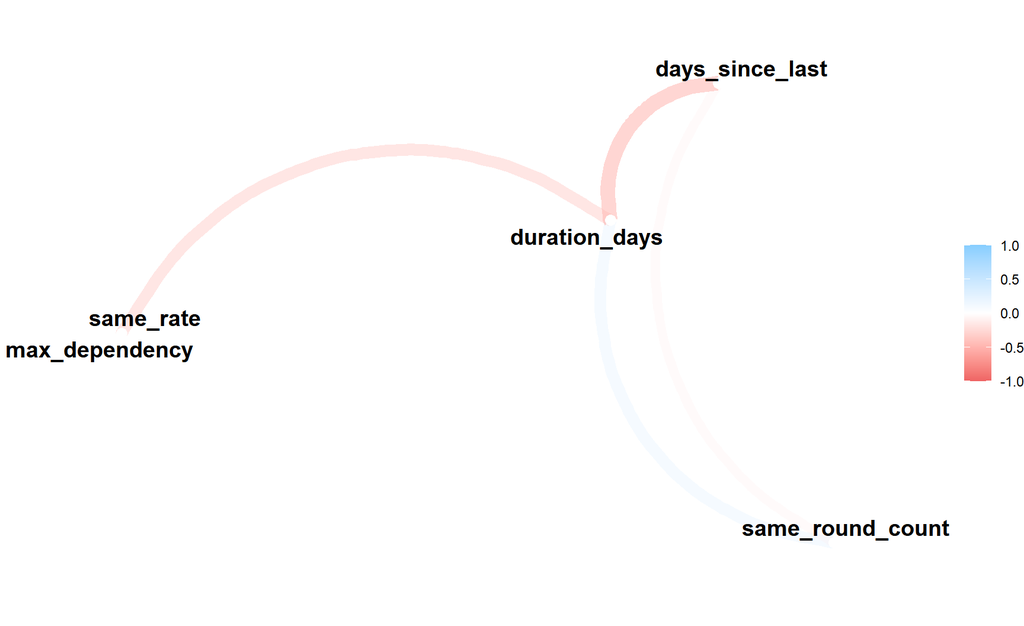

因子相关性网络图

```r
corr_matrix |> network_plot(min_cor = 0.1)
```

### 3.3 风险综合评分（复合相对排名法，`customer_tier_engine.R`）

**方法变更说明**：早期版本用固定权重(0.35/0.30/0.20/0.15) minmax加权，问题是 minmax 对极端离群值极敏感——10万行数据里任何一个 `duration_days` 或 `same_round_count` 的极端值，会把其余99,999行全部压缩到分数区间的很小一段，导致风险分辨识度失真。改用**百分位排名(percentile rank)加权**：每个因子先转换成”在全样本中的相对名次”，再加权求和——对离群值天然稳健，且经过在全量数据上实测验证：绝对阈值(P99 AND P95 AND P50同时满足)在本数据集上会导致最高风险档位命中数为0（已用Python在真实10万行上复算证实），改用相对排名后不会出现这种”结构性零命中”的假安全信号。

```r
th  <- compute_thresholds(pps)
pps <- classify_pair_tier(pps, th)
pps[, risk_score := composite_rank * 100]   # 沿用0-100刻度，兼容下游着色逻辑

summary_tbl <- pps[, .(
  候选总数         = .N,
  `L4实锤合谋_前5%`   = sum(tier == "L4_实锤合谋"),
  L3高危待复核      = sum(tier == "L3_高危待复核"),
  养号型标记数      = sum(farm_flag),
  近7天仍活跃       = sum(days_since_last <= 7),
  持续超30天        = sum(duration_days >= 30),
  平均同桌率        = mean(same_rate),
  平均风险分        = mean(risk_score)
)]

summary_tbl |> gt() |> fmt_number(columns = c(平均同桌率, 平均风险分), decimals = 3) |>
  tab_header(title = "风险画像 KPI 概览（复合相对排名法，10万行全量动态计算）")
```

风险画像 KPI 概览（复合相对排名法，10万行全量动态计算）

| 候选总数 | L4实锤合谋_前5% | L3高危待复核 | 养号型标记数 | 近7天仍活跃 | 持续超30天 | 平均同桌率 | 平均风险分 |
| --- | --- | --- | --- | --- | --- | --- | --- |
| 100000 | 5000 | 5000 | 2580 | 18054 | 24184 | 0.153 | 50.001 |

### 3.4 分布可视化

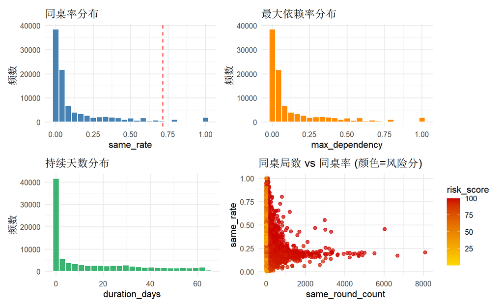

关键因子分布

```r
p1 <- ggplot(pps, aes(same_rate)) +
  geom_histogram(bins = 25, fill = "steelblue", color = "white") +
  geom_vline(xintercept = quantile(pps$same_rate, 0.95), linetype = "dashed", color = "red") +
  labs(title = "同桌率分布", x = "same_rate", y = "频数")

p2 <- ggplot(pps, aes(max_dependency)) +
  geom_histogram(bins = 25, fill = "darkorange", color = "white") +
  labs(title = "最大依赖率分布", x = "max_dependency", y = "频数")

p3 <- ggplot(pps, aes(duration_days)) +
  geom_histogram(bins = 25, fill = "mediumseagreen", color = "white") +
  labs(title = "持续天数分布", x = "duration_days", y = "频数")

p4 <- ggplot(pps, aes(x = same_round_count, y = same_rate, color = risk_score)) +
  geom_point(alpha = 0.7, size = 2) +
  scale_color_gradient(low = "gold", high = "red3") +
  labs(title = "同桌局数 vs 同桌率 (颜色=风险分)", x = "same_round_count", y = "same_rate")

(p1 | p2) / (p3 | p4)
```

### 3.5 风险网络图 (Fraud Ring Detection)

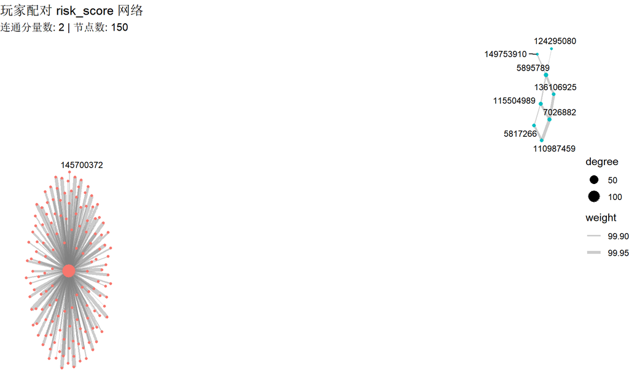

高风险玩家配对关系网络（Top 150条边，全量数据下按固定数量而非分位数截取，避免图形过密无法阅读）

```r
# 注意：全量10万条数据下，quantile(risk_score, 0.70)会保留约3万条边，图形无法渲染/阅读
# 改为固定截取risk_score最高的150条边，这是网络关系图可读性的经验上限
edges <- pps[order(-risk_score)][1:min(150, .N),
             .(from = as.character(player_a), to = as.character(player_b), weight = risk_score)]

g <- graph_from_data_frame(edges, directed = FALSE)
V(g)$degree <- degree(g)
comp <- components(g)
V(g)$component <- comp$membership

ggraph(g, layout = "fr") +
  geom_edge_link(aes(width = weight), alpha = 0.4, color = "grey50") +
  geom_node_point(aes(size = degree, color = factor(component))) +
  geom_node_text(aes(label = name), repel = TRUE, size = 3) +
  scale_edge_width(range = c(0.3, 2)) +
  guides(color = "none") +
  labs(title = "玩家配对 risk_score 网络", subtitle = paste0("连通分量数: ", comp$no, " | 节点数: ", vcount(g))) +
  theme_void()
```

```r
network_stats <- data.table(
  指标 = c("节点总数", "边总数", "连通分量数", "最大连通分量节点数", "全局聚类系数"),
  数值 = c(vcount(g), ecount(g), comp$no, max(comp$csize), round(transitivity(g, type = "global"), 3))
)
network_stats |> gt() |> tab_header(title = "网络拓扑统计")
```

网络拓扑统计

| 指标 | 数值 |
| --- | --- |
| 节点总数 | 150 |
| 边总数 | 150 |
| 连通分量数 | 2 |
| 最大连通分量节点数 | 142 |
| 全局聚类系数 | 0 |

**解读**：连通分量数越少、单个分量节点数越多，说明高风险配对越倾向于**聚集成团伙**而非孤立的两两配对；全局聚类系数越高，说明团伙内部”互相认识”的紧密程度越高，越符合有组织配合作弊的特征。

### 3.6 高风险候选清单

```r
pps[order(-risk_score)][1:min(20, .N), .(
  player_a, player_b, same_round_count, same_rate = round(same_rate, 4),
  max_dependency = round(max_dependency, 4), duration_days = round(duration_days, 1),
  risk_score = round(risk_score, 1)
)] |>
  gt() |>
  data_color(columns = risk_score, colors = scales::col_numeric(c("white", "#d73027"), c(0, 100))) |>
  tab_header(title = "风险分 Top20 候选清单")
```

风险分 Top20 候选清单

| player_a | player_b | same_round_count | same_rate | max_dependency | duration_days | risk_score |
| --- | --- | --- | --- | --- | --- | --- |
| 14841119 | 142946944 | 299 | 0.6719 | 0.6719 | 59.2 | 100 |
| 14841119 | 147120000 | 298 | 0.8032 | 0.8032 | 50.9 | 100 |
| 14841119 | 139863845 | 457 | 0.6428 | 0.6428 | 58.9 | 100 |
| 14841119 | 37296179 | 1197 | 0.6411 | 0.6411 | 56.2 | 100 |
| 14841119 | 142122689 | 718 | 0.7289 | 0.7289 | 51.1 | 100 |
| 14841119 | 147845751 | 138 | 0.7150 | 0.7150 | 59.7 | 100 |
| 14841119 | 149209053 | 522 | 0.6541 | 0.6541 | 55.4 | 100 |
| 14841119 | 129863226 | 2986 | 0.5535 | 0.5535 | 62.6 | 100 |
| 14841119 | 128705395 | 280 | 0.6846 | 0.6846 | 54.0 | 100 |
| 14841119 | 142226683 | 281 | 0.5953 | 0.5953 | 62.6 | 100 |
| 14841119 | 143749380 | 878 | 0.5881 | 0.5881 | 59.2 | 100 |
| 14841119 | 104395297 | 144 | 0.6761 | 0.6761 | 58.2 | 100 |
| 14841119 | 115969109 | 261 | 0.6170 | 0.6170 | 58.1 | 100 |
| 14841119 | 139805517 | 566 | 0.5977 | 0.5977 | 59.1 | 100 |
| 14841119 | 142034801 | 252 | 0.6161 | 0.6161 | 56.1 | 100 |
| 14841119 | 107331607 | 628 | 0.5442 | 0.5442 | 58.4 | 100 |
| 14841119 | 149372052 | 269 | 0.7005 | 0.7005 | 47.8 | 100 |
| 14841119 | 149781623 | 186 | 0.7440 | 0.7440 | 47.9 | 100 |
| 14841119 | 23185062 | 2489 | 0.4698 | 0.4698 | 63.8 | 100 |
| 14841119 | 58448406 | 446 | 0.5180 | 0.5180 | 59.6 | 100 |

### 3.7 扩展风险画像（12项指标，对标行业成熟风控看板标准）

> ℹ️ 样本规模（动态计算，非固定文字）：当前 `player_pair_stat` 共 100,000 行，覆盖时间跨度约 64.8 天。以下全部面板均基于此规模渲染。

```r
# ---- 风险等级分类：直接复用 customer_tier_engine.R 算出的 tier（复合相对排名），
# 不再用 15/30/50/70/85 这种手工拍脑袋的固定断点——那组数字在10万行真实数据下
# 没有任何统计依据，只是"看起来合理"，不符合"必须以数据证明支撑"的要求。
pps[, risk_level_6 := tier]

# ---- 同桌率6档分桶 ----
pps[, same_rate_bin := cut(
  same_rate,
  breaks = c(-Inf, 0.01, 0.05, 0.15, 0.30, 0.50, Inf),
  labels = c("极低(<1%)", "低(1-5%)", "中(5-15%)", "较高(15-30%)", "高(30-50%)", "极高(≥50%)"),
  right = FALSE
)]

# ---- 同桌密度(局/天)，防止除0 ----
pps[, same_density := fifelse(duration_days > 0, same_round_count / duration_days, same_round_count)]

# ---- 活跃度不对称比率 ----
pps[, activity_asymmetry := pmin(player_a_rounds, player_b_rounds) / pmax(player_a_rounds, player_b_rounds)]

# ---- 玩家层面总局数(合并a/b两列做边际分布) ----
player_rounds_pool <- c(pps$player_a_rounds, pps$player_b_rounds)

# ---- 网络度分布：每个玩家连接了多少个不同的"风险搭档" ----
g_full <- graph_from_data_frame(
  pps[, .(from = as.character(player_a), to = as.character(player_b))],
  directed = FALSE
)
degree_dt <- data.table(player = names(degree(g_full)), degree = as.integer(degree(g_full)))
```

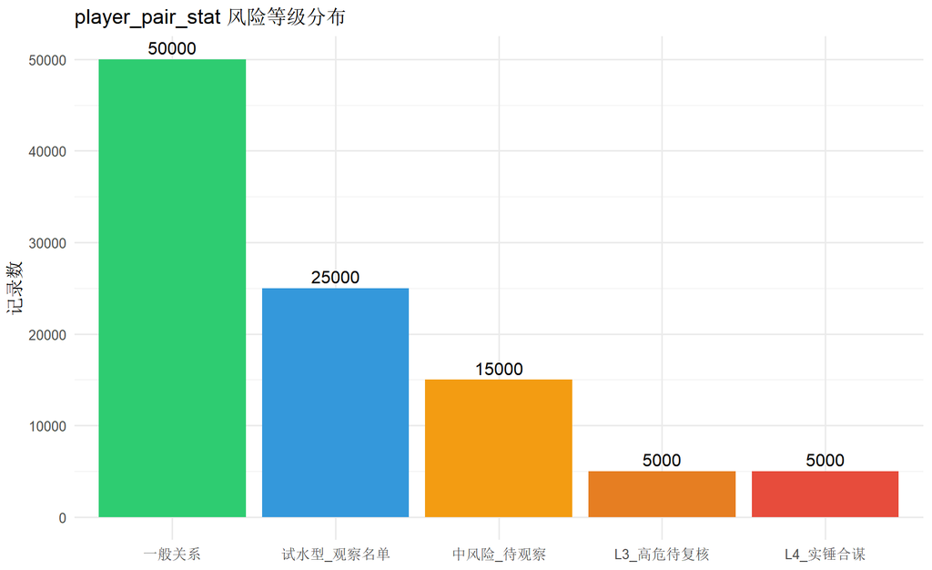

```r
p_level <- ggplot(pps[!is.na(risk_level_6)], aes(risk_level_6, fill = risk_level_6)) +
  geom_bar() +
  geom_text(stat = "count", aes(label = after_stat(count)), vjust = -0.4) +
  scale_fill_manual(values = c("一般关系"="#2ecc71","试水型_观察名单"="#3498db",
                                 "中风险_待观察"="#f39c12","L3_高危待复核"="#e67e22",
                                 "L4_实锤合谋"="#e74c3c")) +
  guides(fill = "none") +
  labs(title = "player_pair_stat 风险等级分布", x = NULL, y = "记录数")
p_level
```

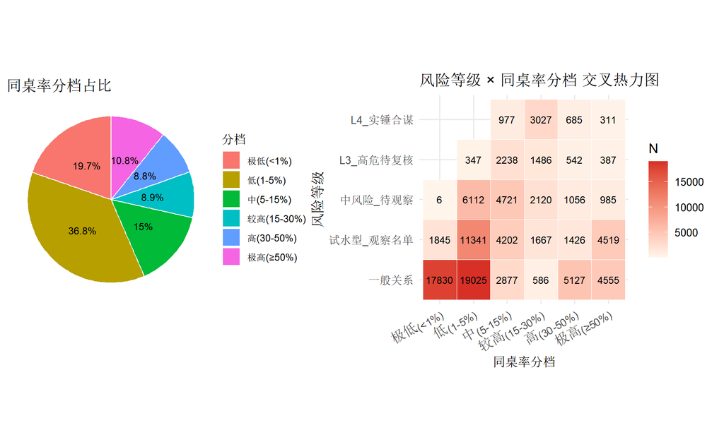

同桌率分档占比 与 风险等级×同桌率分档 交叉热力图

```r
rate_bin_summary <- pps[!is.na(same_rate_bin), .N, by = same_rate_bin]
p_pie <- ggplot(rate_bin_summary, aes(x = "", y = N, fill = same_rate_bin)) +
  geom_col(width = 1, color = "white") +
  coord_polar("y") +
  geom_text(aes(label = paste0(round(N/sum(N)*100,1), "%")), position = position_stack(vjust = 0.5), size = 3.2) +
  theme_void() +
  labs(title = "同桌率分档占比", fill = "分档")

cross_tab <- pps[!is.na(risk_level_6) & !is.na(same_rate_bin), .N, by = .(risk_level_6, same_rate_bin)]
p_heat <- ggplot(cross_tab, aes(same_rate_bin, risk_level_6, fill = N)) +
  geom_tile(color = "white") +
  geom_text(aes(label = N), size = 3) +
  scale_fill_gradient(low = "#fff5eb", high = "#d73027") +
  labs(title = "风险等级 × 同桌率分档 交叉热力图", x = "同桌率分档", y = "风险等级") +
  theme(axis.text.x = element_text(angle = 30, hjust = 1))

p_pie | p_heat
```

[figure not shown]

持续时间 / 总局数(log) / 同桌密度 / 网络度分布

```r
p6 <- ggplot(pps, aes(duration_days)) +
  geom_histogram(bins = 25, fill = "mediumpurple", color = "white") +
  geom_vline(xintercept = mean(pps$duration_days), linetype = "dashed", color = "red") +
  labs(title = "同桌关系持续时间分布", x = "持续天数", y = "频数")

p7 <- ggplot(data.table(total_rounds = player_rounds_pool), aes(log10(total_rounds))) +
  geom_histogram(bins = 25, fill = "#2ecc71", color = "white") +
  labs(title = "玩家总局数分布(log10)", x = "总局数(log10)", y = "频数")

p8 <- ggplot(pps, aes(same_density)) +
  geom_histogram(bins = 25, fill = "darkorange", color = "white") +
  geom_vline(xintercept = mean(pps$same_density), linetype = "dashed", color = "red") +
  labs(title = "同桌密度分布(局/天)", x = "同桌密度", y = "频数")

p9 <- ggplot(degree_dt, aes(degree)) +
  geom_histogram(binwidth = 1, fill = "#16a085", color = "white") +
  geom_vline(xintercept = mean(degree_dt$degree), linetype = "dashed", color = "red") +
  labs(title = "玩家关系网络度分布", x = "关系对数(度)", y = "玩家数")

(p6 | p7) / (p8 | p9)
```

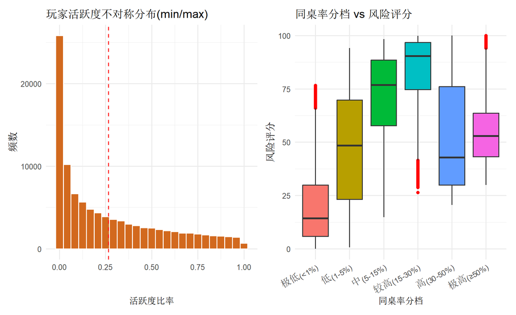

活跃度不对称分布 与 同桌率分档 vs 风险评分箱线图

```r
p10 <- ggplot(pps, aes(activity_asymmetry)) +
  geom_histogram(bins = 25, fill = "chocolate", color = "white") +
  geom_vline(xintercept = mean(pps$activity_asymmetry), linetype = "dashed", color = "red") +
  labs(title = "玩家活跃度不对称分布(min/max)", x = "活跃度比率", y = "频数")

p11 <- ggplot(pps[!is.na(same_rate_bin)], aes(same_rate_bin, risk_score, fill = same_rate_bin)) +
  geom_boxplot(outlier.color = "red") +
  guides(fill = "none") +
  labs(title = "同桌率分档 vs 风险评分", x = "同桌率分档", y = "风险评分") +
  theme(axis.text.x = element_text(angle = 30, hjust = 1))

p10 | p11
```